# Risk Factor Analysis

## Outcome Variable

**Outcome Variable:** ever_wasted

## Predictor Variables

**Intervention Variable:** nrooms

**Adjustment Set:**

- arm
- sex
- W_mage
- meducyrs
- feducyrs
- hhwealth_quart
- hfoodsec
- W_mhtcm
- W_mwtkg
- W_mbmi
- W_nchldlt5
- W_parity
- impfloor
- impsan
- safeh20
- delta_W_mage
- delta_meducyrs
- delta_feducyrs
- delta_hhwealth_quart
- delta_hfoodsec
- delta_W_mhtcm
- delta_W_mwtkg
- delta_W_mbmi
- delta_W_nchldlt5
- delta_W_parity
- delta_impfloor
- delta_impsan
- delta_safeh20

## Stratifying Variables

The analysis was stratified on these variable(s):

- agecat
- studyid
- country

## Data Summary

| agecat | studyid | country | nrooms | ever_wasted | n_cell | n |
| --- | --- | --- | --- | --- | --- | --- |
| 0-24 months | CMC-V-BCS-2002 | INDIA | 4+ | 0 | 9 | 373 |
| 0-24 months | CMC-V-BCS-2002 | INDIA | 4+ | 1 | 5 | 373 |
| 0-24 months | CMC-V-BCS-2002 | INDIA | 1 | 0 | 68 | 373 |
| 0-24 months | CMC-V-BCS-2002 | INDIA | 1 | 1 | 134 | 373 |
| 0-24 months | CMC-V-BCS-2002 | INDIA | 2 | 0 | 43 | 373 |
| 0-24 months | CMC-V-BCS-2002 | INDIA | 2 | 1 | 63 | 373 |
| 0-24 months | CMC-V-BCS-2002 | INDIA | 3 | 0 | 25 | 373 |
| 0-24 months | CMC-V-BCS-2002 | INDIA | 3 | 1 | 26 | 373 |
| 0-24 months | COHORTS | INDIA | 4+ | 0 | 90 | 5366 |
| 0-24 months | COHORTS | INDIA | 4+ | 1 | 16 | 5366 |
| 0-24 months | COHORTS | INDIA | 1 | 0 | 2235 | 5366 |
| 0-24 months | COHORTS | INDIA | 1 | 1 | 1276 | 5366 |
| 0-24 months | COHORTS | INDIA | 2 | 0 | 1089 | 5366 |
| 0-24 months | COHORTS | INDIA | 2 | 1 | 465 | 5366 |
| 0-24 months | COHORTS | INDIA | 3 | 0 | 152 | 5366 |
| 0-24 months | COHORTS | INDIA | 3 | 1 | 43 | 5366 |
| 0-24 months | CONTENT | PERU | 4+ | 0 | 75 | 215 |
| 0-24 months | CONTENT | PERU | 4+ | 1 | 3 | 215 |
| 0-24 months | CONTENT | PERU | 1 | 0 | 42 | 215 |
| 0-24 months | CONTENT | PERU | 1 | 1 | 2 | 215 |
| 0-24 months | CONTENT | PERU | 2 | 0 | 54 | 215 |
| 0-24 months | CONTENT | PERU | 2 | 1 | 0 | 215 |
| 0-24 months | CONTENT | PERU | 3 | 0 | 39 | 215 |
| 0-24 months | CONTENT | PERU | 3 | 1 | 0 | 215 |
| 0-24 months | GMS-Nepal | NEPAL | 4+ | 0 | 116 | 686 |
| 0-24 months | GMS-Nepal | NEPAL | 4+ | 1 | 198 | 686 |
| 0-24 months | GMS-Nepal | NEPAL | 1 | 0 | 22 | 686 |
| 0-24 months | GMS-Nepal | NEPAL | 1 | 1 | 27 | 686 |
| 0-24 months | GMS-Nepal | NEPAL | 2 | 0 | 68 | 686 |
| 0-24 months | GMS-Nepal | NEPAL | 2 | 1 | 75 | 686 |

[output cut: 354 more lines]

The following strata were considered:

- agecat: 0-24 months, studyid: CMC-V-BCS-2002, country: INDIA
- agecat: 0-24 months, studyid: COHORTS, country: INDIA
- agecat: 0-24 months, studyid: CONTENT, country: PERU
- agecat: 0-24 months, studyid: GMS-Nepal, country: NEPAL
- agecat: 0-24 months, studyid: IRC, country: INDIA
- agecat: 0-24 months, studyid: JiVitA-3, country: BANGLADESH
- agecat: 0-24 months, studyid: JiVitA-4, country: BANGLADESH
- agecat: 0-24 months, studyid: MAL-ED, country: BANGLADESH
- agecat: 0-24 months, studyid: MAL-ED, country: BRAZIL
- agecat: 0-24 months, studyid: MAL-ED, country: INDIA
- agecat: 0-24 months, studyid: MAL-ED, country: NEPAL
- agecat: 0-24 months, studyid: MAL-ED, country: PERU
- agecat: 0-24 months, studyid: MAL-ED, country: SOUTH AFRICA
- agecat: 0-24 months, studyid: MAL-ED, country: TANZANIA, UNITED REPUBLIC OF
- agecat: 0-24 months, studyid: NIH-Crypto, country: BANGLADESH
- agecat: 0-24 months, studyid: PROVIDE, country: BANGLADESH
- agecat: 0-6 months, studyid: CMC-V-BCS-2002, country: INDIA
- agecat: 0-6 months, studyid: COHORTS, country: INDIA
- agecat: 0-6 months, studyid: CONTENT, country: PERU
- agecat: 0-6 months, studyid: GMS-Nepal, country: NEPAL
- agecat: 0-6 months, studyid: IRC, country: INDIA
- agecat: 0-6 months, studyid: JiVitA-3, country: BANGLADESH
- agecat: 0-6 months, studyid: JiVitA-4, country: BANGLADESH
- agecat: 0-6 months, studyid: MAL-ED, country: BANGLADESH
- agecat: 0-6 months, studyid: MAL-ED, country: BRAZIL
- agecat: 0-6 months, studyid: MAL-ED, country: INDIA
- agecat: 0-6 months, studyid: MAL-ED, country: NEPAL
- agecat: 0-6 months, studyid: MAL-ED, country: PERU
- agecat: 0-6 months, studyid: MAL-ED, country: SOUTH AFRICA
- agecat: 0-6 months, studyid: MAL-ED, country: TANZANIA, UNITED REPUBLIC OF
- agecat: 0-6 months, studyid: NIH-Crypto, country: BANGLADESH
- agecat: 0-6 months, studyid: PROVIDE, country: BANGLADESH
- agecat: 6-24 months, studyid: CMC-V-BCS-2002, country: INDIA
- agecat: 6-24 months, studyid: COHORTS, country: INDIA
- agecat: 6-24 months, studyid: CONTENT, country: PERU
- agecat: 6-24 months, studyid: GMS-Nepal, country: NEPAL
- agecat: 6-24 months, studyid: IRC, country: INDIA
- agecat: 6-24 months, studyid: JiVitA-3, country: BANGLADESH
- agecat: 6-24 months, studyid: JiVitA-4, country: BANGLADESH
- agecat: 6-24 months, studyid: MAL-ED, country: BANGLADESH
- agecat: 6-24 months, studyid: MAL-ED, country: BRAZIL
- agecat: 6-24 months, studyid: MAL-ED, country: INDIA
- agecat: 6-24 months, studyid: MAL-ED, country: NEPAL
- agecat: 6-24 months, studyid: MAL-ED, country: PERU
- agecat: 6-24 months, studyid: MAL-ED, country: SOUTH AFRICA
- agecat: 6-24 months, studyid: MAL-ED, country: TANZANIA, UNITED REPUBLIC OF
- agecat: 6-24 months, studyid: NIH-Crypto, country: BANGLADESH
- agecat: 6-24 months, studyid: PROVIDE, country: BANGLADESH

### Dropped Strata

Some strata were dropped due to rare outcomes:

- agecat: 0-24 months, studyid: CONTENT, country: PERU
- agecat: 0-24 months, studyid: MAL-ED, country: BANGLADESH
- agecat: 0-24 months, studyid: MAL-ED, country: BRAZIL
- agecat: 0-24 months, studyid: MAL-ED, country: PERU
- agecat: 0-24 months, studyid: MAL-ED, country: SOUTH AFRICA
- agecat: 0-24 months, studyid: MAL-ED, country: TANZANIA, UNITED REPUBLIC OF
- agecat: 0-6 months, studyid: CMC-V-BCS-2002, country: INDIA
- agecat: 0-6 months, studyid: CONTENT, country: PERU
- agecat: 0-6 months, studyid: MAL-ED, country: BANGLADESH
- agecat: 0-6 months, studyid: MAL-ED, country: BRAZIL
- agecat: 0-6 months, studyid: MAL-ED, country: NEPAL
- agecat: 0-6 months, studyid: MAL-ED, country: PERU
- agecat: 0-6 months, studyid: MAL-ED, country: SOUTH AFRICA
- agecat: 0-6 months, studyid: MAL-ED, country: TANZANIA, UNITED REPUBLIC OF
- agecat: 6-24 months, studyid: CMC-V-BCS-2002, country: INDIA
- agecat: 6-24 months, studyid: COHORTS, country: INDIA
- agecat: 6-24 months, studyid: CONTENT, country: PERU
- agecat: 6-24 months, studyid: MAL-ED, country: BANGLADESH
- agecat: 6-24 months, studyid: MAL-ED, country: BRAZIL
- agecat: 6-24 months, studyid: MAL-ED, country: INDIA
- agecat: 6-24 months, studyid: MAL-ED, country: NEPAL
- agecat: 6-24 months, studyid: MAL-ED, country: PERU
- agecat: 6-24 months, studyid: MAL-ED, country: SOUTH AFRICA
- agecat: 6-24 months, studyid: MAL-ED, country: TANZANIA, UNITED REPUBLIC OF
- agecat: 6-24 months, studyid: PROVIDE, country: BANGLADESH

## Methods Detail

We're interested in the causal parameters $E[Y_a]$ for all values of $a \in \mathcal{A}$. These parameters represent the mean outcome if, possibly contrary to fact, we intervened to set all units to have $A=a$. Under the randomization and positivity assumptions, these are identified by the statistical parameters $\psi_a=E_W[E_{Y|A,W}(Y|A=a,W)]$. In addition, we're interested in the mean of $Y$, $E[Y]$ under no intervention (the observed mean). We will estimate these parameters by using SuperLearner to fit the relevant likelihood factors -- $E_{Y|A,W}(Y|A=a,W)$ and $p(A=a|W)$, and then updating our likelihood fit using a joint TMLE.

For unadjusted analyses ($W=\{\}$), initial likelihoods were estimated using Lrnr_glm to estimate the simple $E(Y|A)$ and Lrnr_mean to estimate $p(A)$. For adjusted analyses, a small library containing Lrnr_glmnet, Lrnr_xgboost, and Lrnr_mean was used.

Having estimated these parameters, we will then use the delta method to estimate relative risks and attributable risks relative to a prespecified baseline level of $A$.

# Results Detail

## Results Plots

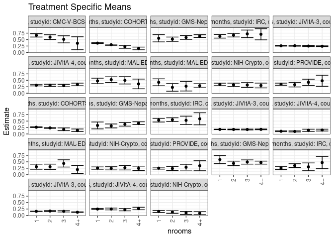

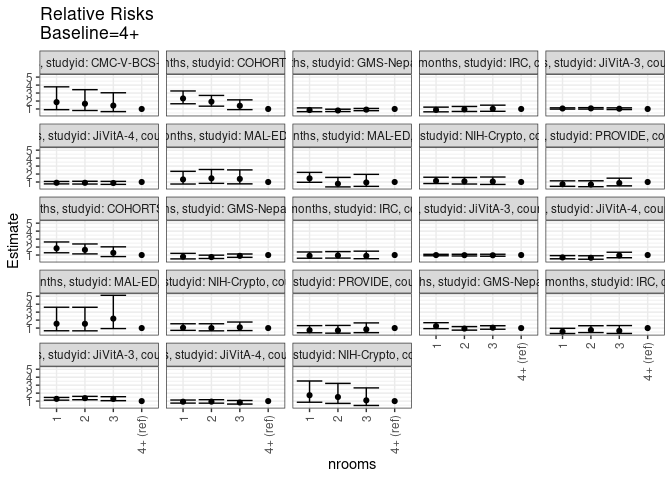

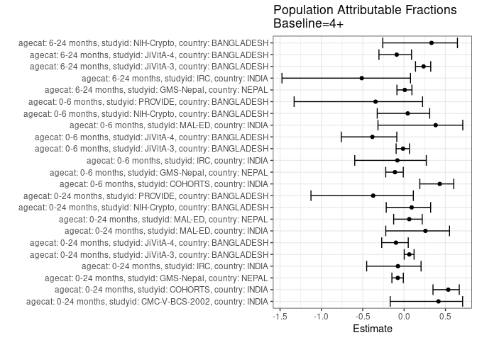

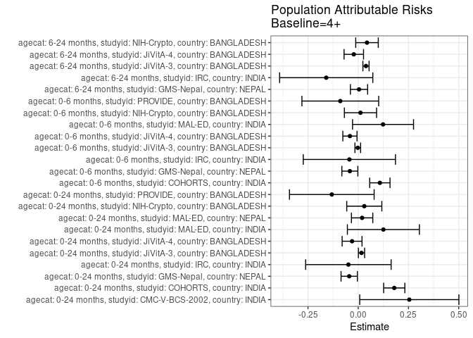

## Results Table

### Parameter: TSM

| agecat | studyid | country | intervention_level | baseline_level | estimate | ci_lower | ci_upper |
| --- | --- | --- | --- | --- | --- | --- | --- |
| 0-24 months | CMC-V-BCS-2002 | INDIA | 4+ | NA | 0.3571429 | 0.1058123 | 0.6084734 |
| 0-24 months | CMC-V-BCS-2002 | INDIA | 1 | NA | 0.6633663 | 0.5981118 | 0.7286209 |
| 0-24 months | CMC-V-BCS-2002 | INDIA | 2 | NA | 0.5943396 | 0.5007394 | 0.6879398 |
| 0-24 months | CMC-V-BCS-2002 | INDIA | 3 | NA | 0.5098039 | 0.3724211 | 0.6471867 |
| 0-24 months | COHORTS | INDIA | 4+ | NA | 0.1562396 | 0.1036785 | 0.2088008 |
| 0-24 months | COHORTS | INDIA | 1 | NA | 0.3626768 | 0.3466682 | 0.3786855 |
| 0-24 months | COHORTS | INDIA | 2 | NA | 0.2988567 | 0.2756209 | 0.3220925 |
| 0-24 months | COHORTS | INDIA | 3 | NA | 0.2192563 | 0.1626440 | 0.2758686 |
| 0-24 months | GMS-Nepal | NEPAL | 4+ | NA | 0.6353509 | 0.5813717 | 0.6893300 |
| 0-24 months | GMS-Nepal | NEPAL | 1 | NA | 0.5511243 | 0.4105046 | 0.6917440 |
| 0-24 months | GMS-Nepal | NEPAL | 2 | NA | 0.5149530 | 0.4319586 | 0.5979473 |
| 0-24 months | GMS-Nepal | NEPAL | 3 | NA | 0.5829884 | 0.5093743 | 0.6566026 |
| 0-24 months | IRC | INDIA | 4+ | NA | 0.7058824 | 0.4890205 | 0.9227442 |
| 0-24 months | IRC | INDIA | 1 | NA | 0.6270270 | 0.5572557 | 0.6967983 |
| 0-24 months | IRC | INDIA | 2 | NA | 0.6705882 | 0.5998500 | 0.7413264 |
| 0-24 months | IRC | INDIA | 3 | NA | 0.7222222 | 0.5757302 | 0.8687142 |
| 0-24 months | JiVitA-3 | BANGLADESH | 4+ | NA | 0.2417484 | 0.2265559 | 0.2569408 |
| 0-24 months | JiVitA-3 | BANGLADESH | 1 | NA | 0.2565057 | 0.2458984 | 0.2671130 |
| 0-24 months | JiVitA-3 | BANGLADESH | 2 | NA | 0.2600389 | 0.2439539 | 0.2761240 |
| 0-24 months | JiVitA-3 | BANGLADESH | 3 | NA | 0.2489908 | 0.2300857 | 0.2678959 |
| 0-24 months | JiVitA-4 | BANGLADESH | 4+ | NA | 0.3407540 | 0.2901003 | 0.3914078 |
| 0-24 months | JiVitA-4 | BANGLADESH | 1 | NA | 0.3081589 | 0.2841370 | 0.3321809 |
| 0-24 months | JiVitA-4 | BANGLADESH | 2 | NA | 0.3071393 | 0.2675153 | 0.3467632 |
| 0-24 months | JiVitA-4 | BANGLADESH | 3 | NA | 0.2970034 | 0.2492942 | 0.3447126 |
| 0-24 months | MAL-ED | INDIA | 4+ | NA | 0.3600000 | 0.1714418 | 0.5485582 |
| 0-24 months | MAL-ED | INDIA | 1 | NA | 0.4761905 | 0.3691590 | 0.5832219 |
| 0-24 months | MAL-ED | INDIA | 2 | NA | 0.5256410 | 0.4145894 | 0.6366927 |
| 0-24 months | MAL-ED | INDIA | 3 | NA | 0.5000000 | 0.3582499 | 0.6417501 |
| 0-24 months | MAL-ED | NEPAL | 4+ | NA | 0.2900763 | 0.2122016 | 0.3679511 |
| 0-24 months | MAL-ED | NEPAL | 1 | NA | 0.4230769 | 0.2885104 | 0.5576435 |

[output cut: 62 more lines]

### Parameter: E(Y)

| agecat | studyid | country | intervention_level | baseline_level | estimate | ci_lower | ci_upper |
| --- | --- | --- | --- | --- | --- | --- | --- |
| 0-24 months | CMC-V-BCS-2002 | INDIA | NA | NA | 0.6112601 | 0.5617242 | 0.6607959 |
| 0-24 months | COHORTS | INDIA | NA | NA | 0.3354454 | 0.3228114 | 0.3480794 |
| 0-24 months | GMS-Nepal | NEPAL | NA | NA | 0.5903790 | 0.5535526 | 0.6272054 |
| 0-24 months | IRC | INDIA | NA | NA | 0.6568627 | 0.6107393 | 0.7029862 |
| 0-24 months | JiVitA-3 | BANGLADESH | NA | NA | 0.2579663 | 0.2514934 | 0.2644392 |
| 0-24 months | JiVitA-4 | BANGLADESH | NA | NA | 0.3101161 | 0.2957091 | 0.3245231 |
| 0-24 months | MAL-ED | INDIA | NA | NA | 0.4851064 | 0.4210714 | 0.5491414 |
| 0-24 months | MAL-ED | NEPAL | NA | NA | 0.3093220 | 0.2502261 | 0.3684179 |
| 0-24 months | NIH-Crypto | BANGLADESH | NA | NA | 0.3298153 | 0.2963239 | 0.3633067 |
| 0-24 months | PROVIDE | BANGLADESH | NA | NA | 0.3514286 | 0.3160364 | 0.3868207 |
| 0-6 months | COHORTS | INDIA | NA | NA | 0.2494186 | 0.2376119 | 0.2612253 |
| 0-6 months | GMS-Nepal | NEPAL | NA | NA | 0.3760933 | 0.3398180 | 0.4123685 |
| 0-6 months | IRC | INDIA | NA | NA | 0.5441176 | 0.4957312 | 0.5925041 |
| 0-6 months | JiVitA-3 | BANGLADESH | NA | NA | 0.1761899 | 0.1705583 | 0.1818216 |
| 0-6 months | JiVitA-4 | BANGLADESH | NA | NA | 0.1078103 | 0.0979894 | 0.1176312 |
| 0-6 months | MAL-ED | INDIA | NA | NA | 0.3234043 | 0.2634696 | 0.3833389 |
| 0-6 months | NIH-Crypto | BANGLADESH | NA | NA | 0.2572559 | 0.2261171 | 0.2883948 |
| 0-6 months | PROVIDE | BANGLADESH | NA | NA | 0.2585714 | 0.2261125 | 0.2910304 |
| 6-24 months | GMS-Nepal | NEPAL | NA | NA | 0.4728814 | 0.4325613 | 0.5132014 |
| 6-24 months | IRC | INDIA | NA | NA | 0.3112745 | 0.2662918 | 0.3562572 |
| 6-24 months | JiVitA-3 | BANGLADESH | NA | NA | 0.1637742 | 0.1576516 | 0.1698967 |
| 6-24 months | JiVitA-4 | BANGLADESH | NA | NA | 0.2472801 | 0.2337480 | 0.2608122 |
| 6-24 months | NIH-Crypto | BANGLADESH | NA | NA | 0.1315068 | 0.1069744 | 0.1560393 |

### Parameter: RR

| agecat | studyid | country | intervention_level | baseline_level | estimate | ci_lower | ci_upper |
| --- | --- | --- | --- | --- | --- | --- | --- |
| 0-24 months | CMC-V-BCS-2002 | INDIA | 4+ | 4+ | 1.0000000 | 1.0000000 | 1.0000000 |
| 0-24 months | CMC-V-BCS-2002 | INDIA | 1 | 4+ | 1.8574257 | 0.9126746 | 3.7801318 |
| 0-24 months | CMC-V-BCS-2002 | INDIA | 2 | 4+ | 1.6641509 | 0.8091128 | 3.4227594 |
| 0-24 months | CMC-V-BCS-2002 | INDIA | 3 | 4+ | 1.4274510 | 0.6718852 | 3.0326854 |
| 0-24 months | COHORTS | INDIA | 4+ | 4+ | 1.0000000 | 1.0000000 | 1.0000000 |
| 0-24 months | COHORTS | INDIA | 1 | 4+ | 2.3212859 | 1.6533291 | 3.2591019 |
| 0-24 months | COHORTS | INDIA | 2 | 4+ | 1.9128097 | 1.3543068 | 2.7016337 |
| 0-24 months | COHORTS | INDIA | 3 | 4+ | 1.4033335 | 0.9183063 | 2.1445405 |
| 0-24 months | GMS-Nepal | NEPAL | 4+ | 4+ | 1.0000000 | 1.0000000 | 1.0000000 |
| 0-24 months | GMS-Nepal | NEPAL | 1 | 4+ | 0.8674330 | 0.6628476 | 1.1351629 |
| 0-24 months | GMS-Nepal | NEPAL | 2 | 4+ | 0.8105018 | 0.6755826 | 0.9723653 |
| 0-24 months | GMS-Nepal | NEPAL | 3 | 4+ | 0.9175850 | 0.7880511 | 1.0684108 |
| 0-24 months | IRC | INDIA | 4+ | 4+ | 1.0000000 | 1.0000000 | 1.0000000 |
| 0-24 months | IRC | INDIA | 1 | 4+ | 0.8882883 | 0.6406895 | 1.2315733 |
| 0-24 months | IRC | INDIA | 2 | 4+ | 0.9500000 | 0.6865201 | 1.3146009 |
| 0-24 months | IRC | INDIA | 3 | 4+ | 1.0231481 | 0.7080395 | 1.4784939 |
| 0-24 months | JiVitA-3 | BANGLADESH | 4+ | 4+ | 1.0000000 | 1.0000000 | 1.0000000 |
| 0-24 months | JiVitA-3 | BANGLADESH | 1 | 4+ | 1.0610443 | 0.9842455 | 1.1438356 |
| 0-24 months | JiVitA-3 | BANGLADESH | 2 | 4+ | 1.0756595 | 0.9885388 | 1.1704582 |
| 0-24 months | JiVitA-3 | BANGLADESH | 3 | 4+ | 1.0299586 | 0.9313768 | 1.1389748 |
| 0-24 months | JiVitA-4 | BANGLADESH | 4+ | 4+ | 1.0000000 | 1.0000000 | 1.0000000 |
| 0-24 months | JiVitA-4 | BANGLADESH | 1 | 4+ | 0.9043442 | 0.7641968 | 1.0701934 |
| 0-24 months | JiVitA-4 | BANGLADESH | 2 | 4+ | 0.9013518 | 0.7431558 | 1.0932230 |
| 0-24 months | JiVitA-4 | BANGLADESH | 3 | 4+ | 0.8716065 | 0.7027679 | 1.0810082 |
| 0-24 months | MAL-ED | INDIA | 4+ | 4+ | 1.0000000 | 1.0000000 | 1.0000000 |
| 0-24 months | MAL-ED | INDIA | 1 | 4+ | 1.3227513 | 0.7480773 | 2.3388906 |
| 0-24 months | MAL-ED | INDIA | 2 | 4+ | 1.4601140 | 0.8300562 | 2.5684199 |
| 0-24 months | MAL-ED | INDIA | 3 | 4+ | 1.3888889 | 0.7656184 | 2.5195482 |
| 0-24 months | MAL-ED | NEPAL | 4+ | 4+ | 1.0000000 | 1.0000000 | 1.0000000 |
| 0-24 months | MAL-ED | NEPAL | 1 | 4+ | 1.4585020 | 0.9619340 | 2.2114076 |

[output cut: 62 more lines]

### Parameter: PAR

| agecat | studyid | country | intervention_level | baseline_level | estimate | ci_lower | ci_upper |
| --- | --- | --- | --- | --- | --- | --- | --- |
| 0-24 months | CMC-V-BCS-2002 | INDIA | 4+ | NA | 0.2541172 | 0.0073804 | 0.5008540 |
| 0-24 months | COHORTS | INDIA | 4+ | NA | 0.1792058 | 0.1264662 | 0.2319453 |
| 0-24 months | GMS-Nepal | NEPAL | 4+ | NA | -0.0449719 | -0.0855955 | -0.0043482 |
| 0-24 months | IRC | INDIA | 4+ | NA | -0.0490196 | -0.2617104 | 0.1636712 |
| 0-24 months | JiVitA-3 | BANGLADESH | 4+ | NA | 0.0162179 | 0.0007774 | 0.0316585 |
| 0-24 months | JiVitA-4 | BANGLADESH | 4+ | NA | -0.0306380 | -0.0801288 | 0.0188529 |
| 0-24 months | MAL-ED | INDIA | 4+ | NA | 0.1251064 | -0.0540303 | 0.3042430 |
| 0-24 months | MAL-ED | NEPAL | 4+ | NA | 0.0192457 | -0.0338976 | 0.0723890 |
| 0-24 months | NIH-Crypto | BANGLADESH | 4+ | NA | 0.0300787 | -0.0572459 | 0.1174032 |
| 0-24 months | PROVIDE | BANGLADESH | 4+ | NA | -0.1315142 | -0.3421494 | 0.0791210 |
| 0-6 months | COHORTS | INDIA | 4+ | NA | 0.1075692 | 0.0570058 | 0.1581326 |
| 0-6 months | GMS-Nepal | NEPAL | 4+ | NA | -0.0417293 | -0.0815095 | -0.0019491 |
| 0-6 months | IRC | INDIA | 4+ | NA | -0.0441176 | -0.2735435 | 0.1853082 |
| 0-6 months | JiVitA-3 | BANGLADESH | 4+ | NA | -0.0022895 | -0.0164217 | 0.0118427 |
| 0-6 months | JiVitA-4 | BANGLADESH | 4+ | NA | -0.0413718 | -0.0766806 | -0.0060630 |
| 0-6 months | MAL-ED | INDIA | 4+ | NA | 0.1234043 | -0.0283498 | 0.2751583 |
| 0-6 months | NIH-Crypto | BANGLADESH | 4+ | NA | 0.0111799 | -0.0689929 | 0.0913528 |
| 0-6 months | PROVIDE | BANGLADESH | 4+ | NA | -0.0892547 | -0.2803091 | 0.1017998 |
| 6-24 months | GMS-Nepal | NEPAL | 4+ | NA | 0.0038709 | -0.0389846 | 0.0467263 |
| 6-24 months | IRC | INDIA | 4+ | NA | -0.1593137 | -0.3911659 | 0.0725384 |
| 6-24 months | JiVitA-3 | BANGLADESH | 4+ | NA | 0.0385786 | 0.0231889 | 0.0539683 |
| 6-24 months | JiVitA-4 | BANGLADESH | 4+ | NA | -0.0221286 | -0.0705519 | 0.0262947 |
| 6-24 months | NIH-Crypto | BANGLADESH | 4+ | NA | 0.0435948 | -0.0124970 | 0.0996865 |

### Parameter: PAF

| agecat | studyid | country | intervention_level | baseline_level | estimate | ci_lower | ci_upper |
| --- | --- | --- | --- | --- | --- | --- | --- |
| 0-24 months | CMC-V-BCS-2002 | INDIA | 4+ | NA | 0.4157268 | -0.1682288 | 0.7077840 |
| 0-24 months | COHORTS | INDIA | 4+ | NA | 0.5342323 | 0.3491951 | 0.6666596 |
| 0-24 months | GMS-Nepal | NEPAL | 4+ | NA | -0.0761745 | -0.1475626 | -0.0092274 |
| 0-24 months | IRC | INDIA | 4+ | NA | -0.0746269 | -0.4526773 | 0.2050382 |
| 0-24 months | JiVitA-3 | BANGLADESH | 4+ | NA | 0.0628684 | 0.0014560 | 0.1205039 |
| 0-24 months | JiVitA-4 | BANGLADESH | 4+ | NA | -0.0987951 | -0.2709694 | 0.0500553 |
| 0-24 months | MAL-ED | INDIA | 4+ | NA | 0.2578947 | -0.2216217 | 0.5491892 |
| 0-24 months | MAL-ED | NEPAL | 4+ | NA | 0.0622190 | -0.1262521 | 0.2191506 |
| 0-24 months | NIH-Crypto | BANGLADESH | 4+ | NA | 0.0911985 | -0.2161482 | 0.3208722 |
| 0-24 months | PROVIDE | BANGLADESH | 4+ | NA | -0.3742275 | -1.1260674 | 0.1117398 |
| 0-6 months | COHORTS | INDIA | 4+ | NA | 0.4312799 | 0.1898503 | 0.6007619 |
| 0-6 months | GMS-Nepal | NEPAL | 4+ | NA | -0.1109547 | -0.2220958 | -0.0099210 |
| 0-6 months | IRC | INDIA | 4+ | NA | -0.0810811 | -0.5969182 | 0.2681301 |
| 0-6 months | JiVitA-3 | BANGLADESH | 4+ | NA | -0.0129947 | -0.0965670 | 0.0642084 |
| 0-6 months | JiVitA-4 | BANGLADESH | 4+ | NA | -0.3837458 | -0.7596265 | -0.0881584 |
| 0-6 months | MAL-ED | INDIA | 4+ | NA | 0.3815789 | -0.3160749 | 0.7094051 |
| 0-6 months | NIH-Crypto | BANGLADESH | 4+ | NA | 0.0434584 | -0.3248986 | 0.3094024 |
| 0-6 months | PROVIDE | BANGLADESH | 4+ | NA | -0.3451838 | -1.3297335 | 0.2232934 |
| 6-24 months | GMS-Nepal | NEPAL | 4+ | NA | 0.0081857 | -0.0867116 | 0.0947961 |
| 6-24 months | IRC | INDIA | 4+ | NA | -0.5118110 | -1.4765926 | 0.0771302 |
| 6-24 months | JiVitA-3 | BANGLADESH | 4+ | NA | 0.2355598 | 0.1378724 | 0.3221782 |
| 6-24 months | JiVitA-4 | BANGLADESH | 4+ | NA | -0.0894880 | -0.3042176 | 0.0898880 |
| 6-24 months | NIH-Crypto | BANGLADESH | 4+ | NA | 0.3315018 | -0.2585387 | 0.6449137 |